# **Parking Slot Occupancy Detection**

#### 5.2.6. run the code every 2 seconds for 10 iterations and collect the output in a time-based table

```python
import pandas as pd
import pytz
import numpy as np
import matplotlib.pyplot as plt
import geopandas as gpd
import contextily as ctx
from sklearn.svm import SVR
from sklearn.preprocessing import MinMaxScaler
from sklearn.metrics import mean_squared_error
from statsmodels.tsa.arima.model import ARIMA
from prophet import Prophet
from datetime import datetime, timedelta
import time

# Function to run the forecasting process
def run_forecasting_iteration():
    # API details
    base_url = 'https://data.melbourne.vic.gov.au/api/explore/v2.1/catalog/datasets/'
    dataset_id = 'on-street-parking-bay-sensors'

    # Fetch the dataset from the API
    url = f"{base_url}{dataset_id}/exports/csv"
    df = pd.read_csv(url, delimiter=';')

    # Define the timezone conversion function
    def convert_utc_to_melbourne(utc_time_str):
        melbourne_zone = pytz.timezone('Australia/Melbourne')
        utc_time = pd.to_datetime(utc_time_str, utc=True)
        melbourne_time = utc_time.tz_convert(melbourne_zone)
        return melbourne_time

    # Convert the specified columns
    columns_to_convert = ['lastupdated', 'status_timestamp']
    for column in columns_to_convert:
        if column in df.columns:
            df[column] = df[column].apply(lambda x: convert_utc_to_melbourne(x) if pd.notnull(x) else x)

    # Filter data to include only rows from the last 15 minutes
    fifteen_minutes_ago = pd.Timestamp.now(pytz.timezone('Australia/Melbourne')) - timedelta(minutes=15)
    df = df[df['status_timestamp'] >= fifteen_minutes_ago]

    # Calculate the total number of unique kerbside IDs in the dataset
    total_kerbside_ids = df['kerbsideid'].nunique()

    # Filter to include only rows where status_description is 'Present'
    df_present = df[df['status_description'] == 'Present']

    # Resample data to a minute frequency to find the number of 'Present' statuses per kerbside ID
    df_minutely = df_present.resample('T', on='status_timestamp').agg({
        'kerbsideid': 'count'
    })

    # Normalize the data for SVR
    scaler = MinMaxScaler(feature_range=(0, 1))
    df_minutely_scaled = scaler.fit_transform(df_minutely)

    # Prepare the dataset for SVR
    look_back = 1
    X, Y = [], []
    for i in range(len(df_minutely_scaled) - look_back):
        X.append(df_minutely_scaled[i:(i + look_back), 0])
        Y.append(df_minutely_scaled[i + look_back, 0])
    X, Y = np.array(X), np.array(Y)

    # Reshape input to be [samples, features]
    X = np.reshape(X, (X.shape[0], look_back))

    # Split into train and test sets
    train_size = int(len(X) * 0.8)
    test_size = len(X) - train_size
    X_train, X_test = X[0:train_size], X[train_size:]
    Y_train, Y_test = Y[0:train_size], Y[train_size:]

    # Fit the SVR model
    svr_model = SVR(kernel='rbf', C=1e3, gamma=0.1)
    svr_model.fit(X_train, Y_train)

    # Make predictions with SVR
    svr_predict = svr_model.predict(X_test)
    svr_predict = scaler.inverse_transform(svr_predict.reshape(-1, 1))

    # Fit the ARIMA model
    arima_order = (2, 1, 2)  # Example order, you may need to experiment with this
    arima_model = ARIMA(df_minutely['kerbsideid'], order=arima_order)
    arima_model_fit = arima_model.fit()

    # Forecast with ARIMA
    arima_predict = arima_model_fit.forecast(steps=len(X_test)).values.reshape(-1, 1)

    # Prepare data for Prophet model
    df_prophet = df_present[['status_timestamp', 'kerbsideid']].resample('T', on='status_timestamp').count().reset_index()
    df_prophet.columns = ['ds', 'y']

    # Remove timezone information
    df_prophet['ds'] = df_prophet['ds'].dt.tz_localize(None)

    # Fit the Prophet model
    prophet_model = Prophet(interval_width=0.95)
    prophet_model.fit(df_prophet)

    # Forecast with Prophet
    future = prophet_model.make_future_dataframe(periods=len(X_test), freq='T')
    forecast_prophet = prophet_model.predict(future)
    prophet_predict = forecast_prophet['yhat'].values[-len(X_test):].reshape(-1, 1)

    # Combine predictions using a simple average
    combined_predict = (svr_predict + arima_predict + prophet_predict) / 3

    # Calculate available spots based on combined forecast
    forecast_occupied = combined_predict.sum()
    forecast_available = total_kerbside_ids - forecast_occupied
    forecast_available_rounded = round(forecast_available)

    return pd.Timestamp.now(), forecast_available_rounded

# Initialize a list to store the results
results = []

# Run the code every 2 seconds for 10 iterations
for _ in range(10):
    timestamp, available_spots = run_forecasting_iteration()
    results.append({'Time': timestamp, 'Available Spots': available_spots})
    time.sleep(2)

# Convert results to a DataFrame
results_df = pd.DataFrame(results)

# Display the results
print(results_df)

# Optionally, write the results to a CSV file
output_csv = 'forecasted_parking_spots_time_based.csv'
results_df.to_csv(output_csv, index=False)
print(f"Results have been written to {output_csv}")
```

[output not shown]

[output cut: 73 more lines]

[output not shown]

```
                        Time  Available Spots
0 2024-09-19 21:40:39.943547              368
1 2024-09-19 21:40:52.810270              365
2 2024-09-19 21:41:05.541207              362
3 2024-09-19 21:41:18.975768              352
4 2024-09-19 21:41:32.663126              349
5 2024-09-19 21:41:45.445034              348
6 2024-09-19 21:41:59.344311              336
7 2024-09-19 21:42:14.034988              343
8 2024-09-19 21:42:27.428431              335
9 2024-09-19 21:42:40.979813              327
Results have been written to forecasted_parking_spots_time_based.csv
```

## 6. Data Drifting

Comments on the dataset for accuracy: 2 data set information, 5 minutes interval between the dataset, each belongs to the last 15 minutes data, (3 minute resampling is done)

to make an easy comparison, normalization is done

for Kolmogorov-Smirnov Test, A significant p-value would indicate that the distribution of the data in these 5-minute intervals has drifted from the original training data, suggesting that the data properties have changed.

Histograms and KDE Plots: Visualize and compare the distributions of the two datasets. Kernel Density Estimate(KDE):visualizing the Probability Density of a continuous variable.

Correlation Matrix Heatmaps: Compare the correlation patterns to detect any structural changes in the data.

Resample data

Time Occupied 2024-09-03 10:00:00 1 2024-09-03 10:01:00 0 2024-09-03 10:02:00 1 2024-09-03 10:03:00 1 2024-09-03 10:04:00 0 2024-09-03 10:05:00 1 ... Resampling to 3-Minute Intervals:

When you resample this data to 3 minute intervals, the data will be grouped into blocks of 3 minutes

Resampled Time Occupied (Count) 2024-09-03 10:00:00 3 (Count of "1"s from 10:00:00 to 10:02:59) 2024-09-03 10:03:00 2 (Count of "1"s from 10:03:00 to 10:05:59) ... The Reason I do Resampling the dataset in 3 minute blocks. Reduce noise with decreasing rapid fluctuations. To identify broader patterns over slightly longer periods. Reduce the volume of data points, make it easier to manage and analyze for longer periods.

Normalization in the code

Example: In the parking data set, the kerbsideid counts can change a lot and frequently, so some 3-minute intervals having very high counts and others having low counts. Normalizing these counts guuarantee that the range of values is consistent across all intervals.

So, Normalization all the data points are on a similar scale, typically between 0 and 1.

Interpratation of the Graph - KDE PLOT GRAPH - KERNEL DENSITY ESTIMATE

*Height of Peaks: The height of the peaks indicates the density of data points around that value. Higher peaks means that many data points are clustered around that value, showing a strong preference in the data at that specific value.

*Width of the Distribution Narrow or Wide: If one dataset has a much wider distribution than the other, this shows that the values in that dataset are more varied.

Overlap Between Distributions: Significant Overlap: If the KDE plots for the two datasets overlap significantly, it indicates that the distributions are quite similar. This would suggest minimal data drift between the two time periods. Little or No Overlap: If there is little overlap between the KDE plots, this suggests a significant difference in the distributions, which may indicate data drift.

Tails of the Distribution Symmetry: If the KDE plot is symmetric, it suggests that the data is evenly distributed around the mean. Symmetry in both plots indicates that both datasets have similar central tendencies. Skewness: If one KDE plot is skewed to the left or right , it shows that the data is not evenly distributed. A change in skewness between the two datasets may suggest a shift in the underlying data distribution.

```
First dataset has been saved to first_dataset.csv
```

```
Second dataset has been saved to second_dataset.csv
Kolmogorov-Smirnov Test Statistic: 0.5500, p-value: 0.4286
```

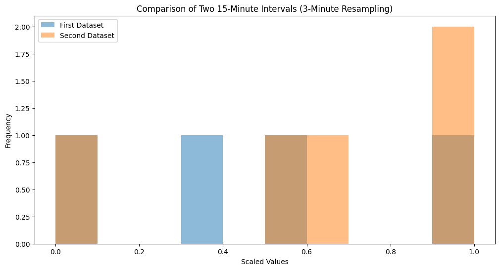

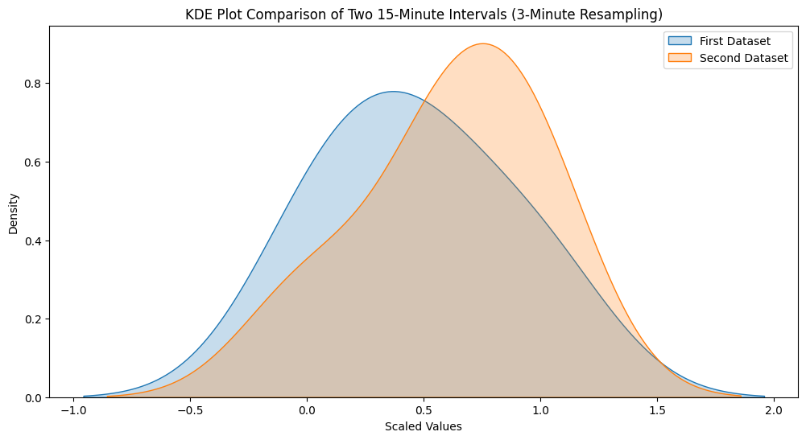

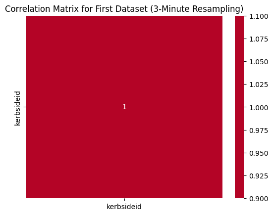

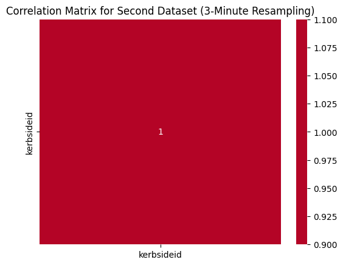

```python
import pandas as pd
import pytz
from datetime import datetime, timedelta
import matplotlib.pyplot as plt
import seaborn as sns
from sklearn.preprocessing import MinMaxScaler
from scipy.stats import ks_2samp
import time

# Function to fetch and process the dataset
def fetch_and_process_data():
    # API details
    base_url = 'https://data.melbourne.vic.gov.au/api/explore/v2.1/catalog/datasets/'
    dataset_id = 'on-street-parking-bay-sensors'

    # Fetch the dataset from the API
    url = f"{base_url}{dataset_id}/exports/csv"
    df = pd.read_csv(url, delimiter=';')

    # Define the timezone conversion function
    def convert_utc_to_melbourne(utc_time_str):
        melbourne_zone = pytz.timezone('Australia/Melbourne')
        utc_time = pd.to_datetime(utc_time_str, utc=True)
        melbourne_time = utc_time.tz_convert(melbourne_zone)
        return melbourne_time

    # Convert the specified columns
    columns_to_convert = ['lastupdated', 'status_timestamp']
    for column in columns_to_convert:
        if column in df.columns:
            df[column] = df[column].apply(lambda x: convert_utc_to_melbourne(x) if pd.notnull(x) else x)

    # Define the interval to capture data (last 15 minutes)
    fifteen_minutes_ago = pd.Timestamp.now(pytz.timezone('Australia/Melbourne')) - timedelta(minutes=15)
    df_filtered = df[df['status_timestamp'] >= fifteen_minutes_ago]

    # Resample data to a 3-minute frequency
    df_resampled = df_filtered.resample('3T', on='status_timestamp').agg({
        'kerbsideid': 'count'
    })

    # Normalize the data
    scaler = MinMaxScaler(feature_range=(0, 1))
    df_resampled_scaled = scaler.fit_transform(df_resampled)

    return df_resampled_scaled

# Capture the first dataset now
df_first_resampled_scaled = fetch_and_process_data()

# Save the first dataset to a CSV file for comparison
output_file_first = 'first_dataset.csv'
pd.DataFrame(df_first_resampled_scaled, columns=['kerbsideid']).to_csv(output_file_first, index=False)
print(f"First dataset has been saved to {output_file_first}")

# Wait for 5 minutes
time.sleep(300)  # Sleep for 300 seconds (5 minutes)

# Capture the second dataset after 5 minutes
df_second_resampled_scaled = fetch_and_process_data()

# Save the second dataset to a CSV file for comparison
output_file_second = 'second_dataset.csv'
pd.DataFrame(df_second_resampled_scaled, columns=['kerbsideid']).to_csv(output_file_second, index=False)
print(f"Second dataset has been saved to {output_file_second}")

# Load the first and second datasets
df_first_resampled_scaled = pd.read_csv('first_dataset.csv')
df_second_resampled_scaled = pd.read_csv('second_dataset.csv')

# Statistical test for data drift: Kolmogorov-Smirnov test
ks_stat, ks_p_value = ks_2samp(df_first_resampled_scaled['kerbsideid'], df_second_resampled_scaled['kerbsideid'])
print(f'Kolmogorov-Smirnov Test Statistic: {ks_stat:.4f}, p-value: {ks_p_value:.4f}')

# Visualization of data drift

# Histograms to compare distributions
plt.figure(figsize=(12, 6))
plt.hist(df_first_resampled_scaled['kerbsideid'], bins=10, alpha=0.5, label='First Dataset')
plt.hist(df_second_resampled_scaled['kerbsideid'], bins=10, alpha=0.5, label='Second Dataset')
plt.title('Comparison of Two 15-Minute Intervals (3-Minute Resampling)')
plt.xlabel('Scaled Values')
plt.ylabel('Frequency')
plt.legend()
plt.show()

# KDE plots to compare distributions
plt.figure(figsize=(12, 6))
sns.kdeplot(df_first_resampled_scaled['kerbsideid'], label='First Dataset', shade=True)
sns.kdeplot(df_second_resampled_scaled['kerbsideid'], label='Second Dataset', shade=True)
plt.title('KDE Plot Comparison of Two 15-Minute Intervals (3-Minute Resampling)')
plt.xlabel('Scaled Values')
plt.ylabel('Density')
plt.legend()
plt.show()

# Heatmap to check for data drift in correlation
sns.heatmap(df_first_resampled_scaled.corr(), annot=True, cmap='coolwarm', center=0)
plt.title('Correlation Matrix for First Dataset (3-Minute Resampling)')
plt.show()

sns.heatmap(df_second_resampled_scaled.corr(), annot=True, cmap='coolwarm', center=0)
plt.title('Correlation Matrix for Second Dataset (3-Minute Resampling)')
plt.show()
```

## 7. Quantitative Measuring for Data Drift: 3 ways to measure

Kolmogorov-Smirnov Test:

****Statistic (ks_stat): Indicates the maximum difference between the cumulative distributions of the two datasets. A higher value indicates more significant drift.** ***p-value (ks_p_value): Helps determine whether the observed drift is statistically significant. A low p-value (typically < 0.05) suggests significant drift.

Other Data Drift Measuring Techniques

Earth Mover's Distance (EMD):

EMD: Represents the minimum "work" needed to transform one distribution into another. Higher values indicate that the distributions are more different, suggesting greater drift.

Jensen-Shannon Divergence (JSD):

JSD: Measures the divergence between the two distributions. The result ranges from 0 (no divergence) to 1 (complete divergence). A higher JSD indicates more drift.

```python
import pandas as pd
import pytz
from datetime import timedelta
from sklearn.preprocessing import MinMaxScaler
from scipy.stats import ks_2samp, wasserstein_distance
from scipy.spatial.distance import jensenshannon
import time

# Function to fetch and process the dataset
def fetch_and_process_data():
    base_url = 'https://data.melbourne.vic.gov.au/api/explore/v2.1/catalog/datasets/'
    dataset_id = 'on-street-parking-bay-sensors'
    url = f"{base_url}{dataset_id}/exports/csv"
    df = pd.read_csv(url, delimiter=';')

    def convert_utc_to_melbourne(utc_time_str):
        melbourne_zone = pytz.timezone('Australia/Melbourne')
        utc_time = pd.to_datetime(utc_time_str, utc=True)
        melbourne_time = utc_time.tz_convert(melbourne_zone)
        return melbourne_time

    columns_to_convert = ['lastupdated', 'status_timestamp']
    for column in columns_to_convert:
        if column in df.columns:
            df[column] = df[column].apply(lambda x: convert_utc_to_melbourne(x) if pd.notnull(x) else x)

    fifteen_minutes_ago = pd.Timestamp.now(pytz.timezone('Australia/Melbourne')) - timedelta(minutes=15)
    df_filtered = df[df['status_timestamp'] >= fifteen_minutes_ago]

    df_resampled = df_filtered.resample('3T', on='status_timestamp').agg({
        'kerbsideid': 'count'
    })

    scaler = MinMaxScaler(feature_range=(0, 1))
    df_resampled_scaled = scaler.fit_transform(df_resampled)

    return df_resampled_scaled

# Capture datasets for comparison
df_first_resampled_scaled = fetch_and_process_data()
output_file_first = 'first_dataset.csv'
pd.DataFrame(df_first_resampled_scaled, columns=['kerbsideid']).to_csv(output_file_first, index=False)

time.sleep(300)  # Sleep for 5 minutes

df_second_resampled_scaled = fetch_and_process_data()
output_file_second = 'second_dataset.csv'
pd.DataFrame(df_second_resampled_scaled, columns=['kerbsideid']).to_csv(output_file_second, index=False)

# Load datasets
df_first_resampled_scaled = pd.read_csv('first_dataset.csv')
df_second_resampled_scaled = pd.read_csv('second_dataset.csv')

# Kolmogorov-Smirnov Test
ks_stat, ks_p_value = ks_2samp(df_first_resampled_scaled['kerbsideid'], df_second_resampled_scaled['kerbsideid'])

# Earth Mover's Distance (EMD)
emd = wasserstein_distance(df_first_resampled_scaled['kerbsideid'], df_second_resampled_scaled['kerbsideid'])

# Jensen-Shannon Divergence (JSD)
jsd = jensenshannon(df_first_resampled_scaled['kerbsideid'], df_second_resampled_scaled['kerbsideid'], base=2)

# Create a comparison table
comparison_data = {
    "Metrics": ["Kolmogorov-Smirnov Statistic", "Kolmogorov-Smirnov p-value", "Earth Mover's Distance (EMD)", "Jensen-Shannon Divergence (JSD)"],
    "Values": [ks_stat, ks_p_value, emd, jsd]
}

comparison_df = pd.DataFrame(comparison_data)

# Print the comparison table
print("\nComparison Table:")
print(comparison_df)
```

```
Comparison Table:
                           Metrics    Values
0     Kolmogorov-Smirnov Statistic  0.400000
1       Kolmogorov-Smirnov p-value  0.873016
2     Earth Mover's Distance (EMD)  0.049623
3  Jensen-Shannon Divergence (JSD)  0.041328
```

#### 7.1.1. Interpretation of the above results

the p-value in Kolmogorov-Smirmnov method, Test is specific to the Kolmogorov-Smirnov (KS) test. It is a test of the model that two samples came from similar distributions. It also helps to determine whether the observed differences between the distributions are statistically significant using the p-values:

A low p-value (< 0.05) tells that the distributions are significantly different. A high p-value (>= 0.05) tells there is no significant difference between the distributions.

The Earth Mover's Distance (EMD) & Jensen-Shannon Divergence (JSD) are the other measuring models of the dissimilarity between two distributions. They do not have a p-value. They are directly measure the "difference" or "cost" of transforming one distribution into the other.

Detailed comments of the Results

Conclusion: Based on the Kolmogorov-Smirnov EMD, and JSD results: There have been no extensive signs of significant data shifts between these datasets throughout the periods. Despite small variations within their distributions which differentiate them from each other,As such, one would say that the parking bay sensor data has remained quite constant across both trials.

If we think about the Medium-term predictions: such as Long Short-Term Memory (LSTM) and spatio-temporal models, These methods use historical parking data combined with external factors like weather or traffic conditions. Studies indicate that medium-term forecasts of up to 2 to 3 hours are usually very realistic, particular to commercial regions.

Melbourne Municipality's Needs: For Melbourne municipality, real-time parking prediction and medium-term forecasting are very vital for managing urban mobility effectively. The city’s Transport Strategy 2030 tells reducing congestion and enhancing parking management as the important goals. The City of Melbourne has also declared that the need for data-driven solutions for parking allocation.

LSTM Model: This model is used for the Prediction

```python
import pandas as pd
import pytz
import numpy as np
from sklearn.preprocessing import MinMaxScaler
from sklearn.metrics import mean_squared_error
from tensorflow.keras.models import Sequential
from tensorflow.keras.layers import LSTM, Dense
from scipy.stats import ks_2samp, wasserstein_distance
from scipy.spatial.distance import jensenshannon
from datetime import timedelta

# Function to fetch and process the dataset
def fetch_and_process_data():
    base_url = 'https://data.melbourne.vic.gov.au/api/explore/v2.1/catalog/datasets/'
    dataset_id = 'on-street-parking-bay-sensors'
    url = f"{base_url}{dataset_id}/exports/csv"
    df = pd.read_csv(url, delimiter=';')

    def convert_utc_to_melbourne(utc_time_str):
        melbourne_zone = pytz.timezone('Australia/Melbourne')
        utc_time = pd.to_datetime(utc_time_str, utc=True)
        melbourne_time = utc_time.tz_convert(melbourne_zone)
        return melbourne_time

    columns_to_convert = ['lastupdated', 'status_timestamp']
    for column in columns_to_convert:
        if column in df.columns:
            df[column] = df[column].apply(lambda x: convert_utc_to_melbourne(x) if pd.notnull(x) else x)

    two_hours_ago = pd.Timestamp.now(pytz.timezone('Australia/Melbourne')) - timedelta(hours=2)
    df_filtered = df[df['status_timestamp'] >= two_hours_ago]

    df_resampled = df_filtered.resample('3T', on='status_timestamp').agg({
        'kerbsideid': 'count'
    }).fillna(0)

    scaler = MinMaxScaler(feature_range=(0, 1))
    df_resampled_scaled = scaler.fit_transform(df_resampled)

    return df_resampled_scaled, scaler

# Split data into features (X) and targets (Y) with look-back window
def split_data(df_resampled_scaled, time_steps=20):  # Reduced time_steps to 20
    X, y = [], []
    for i in range(len(df_resampled_scaled) - time_steps - 1):
        X.append(df_resampled_scaled[i:(i + time_steps), 0])  # Collecting the last 'time_steps' observations
        y.append(df_resampled_scaled[i + time_steps, 0])  # The target is the next observation
    return np.array(X), np.array(y)

# LSTM model creation
def build_lstm_model(time_steps=20):  # Updated to match the new time_steps
    model = Sequential()
    model.add(LSTM(50, return_sequences=False, input_shape=(time_steps, 1)))
    model.add(Dense(1))
    model.compile(optimizer='adam', loss='mse')
    return model

# LSTM Forecast function
def lstm_forecast(df_resampled_scaled, scaler, time_steps=20):
    X, y = split_data(df_resampled_scaled, time_steps)

    # Check if we have enough data points
    if len(X) == 0:
        raise ValueError(f"Not enough data points for the given time_steps ({time_steps}). Try reducing the time_steps.")

    print(f"Number of available data points: {len(X)}")

    X = np.reshape(X, (X.shape[0], X.shape[1], 1))  # Reshaping into [samples, time_steps, features]

    # Splitting the data into training and testing sets
    split_index = int(len(X) * 0.8)
    X_train, X_test = X[:split_index], X[split_index:]
    y_train, y_test = y[:split_index], y[split_index:]

    # Build and train LSTM model
    lstm_model = build_lstm_model(time_steps)
    lstm_model.fit(X_train, y_train, epochs=5, batch_size=32, verbose=2)

    # Generate predictions on the test data
    lstm_predictions = lstm_model.predict(X_test)

    # Inverse transform the predictions and actual values
    lstm_predictions_inverse = scaler.inverse_transform(lstm_predictions)
    y_test_inverse = scaler.inverse_transform(y_test.reshape(-1, 1))

    return lstm_predictions_inverse, y_test_inverse

# Execute LSTM model
df_resampled_scaled, scaler = fetch_and_process_data()
lstm_predictions, y_test_actual = lstm_forecast(df_resampled_scaled, scaler, time_steps=20)

# Kolmogorov-Smirnov Test
ks_stat_lstm, ks_p_value_lstm = ks_2samp(lstm_predictions.flatten(), y_test_actual.flatten())

# Earth Mover's Distance (EMD)
emd_lstm = wasserstein_distance(lstm_predictions.flatten(), y_test_actual.flatten())

# Jensen-Shannon Divergence (JSD)
jsd_lstm = jensenshannon(lstm_predictions.flatten(), y_test_actual.flatten())

# Print Results for LSTM
print(f"LSTM Model:")
print(f"Kolmogorov-Smirnov Statistic: {ks_stat_lstm:.4f}, p-value: {ks_p_value_lstm:.4f}")
print(f"Earth Mover's Distance (EMD): {emd_lstm:.4f}")
print(f"Jensen-Shannon Divergence (JSD): {jsd_lstm:.4f}")
```

```
Number of available data points: 19
```

```
1/1 - 3s - 3s/step - loss: 0.3212
1/1 - 0s - 58ms/step - loss: 0.2924
1/1 - 0s - 55ms/step - loss: 0.2651
1/1 - 0s - 63ms/step - loss: 0.2391
1/1 - 0s - 56ms/step - loss: 0.2142
WARNING:tensorflow:5 out of the last 11 calls to <function TensorFlowTrainer.make_predict_function.<locals>.one_step_on_data_distributed at 0x00000145F50A5580> triggered tf.function retracing. Tracing is expensive and the excessive number of tracings could be due to (1) creating @tf.function repeate…
1/1 ━━━━━━━━━━━━━━━━━━━━ 0s 319ms/step
LSTM Model:
Kolmogorov-Smirnov Statistic: 1.0000, p-value: 0.0286
Earth Mover's Distance (EMD): 74.7393
Jensen-Shannon Divergence (JSD): 0.0379
```

### 7.2.Plot the predicted available spots melbourne city map

```
Number of available data points: 10
```

```
1/1 - 2s - 2s/step - loss: 0.3544
1/1 - 0s - 60ms/step - loss: 0.3187
1/1 - 0s - 62ms/step - loss: 0.2847
1/1 - 0s - 60ms/step - loss: 0.2523
1/1 - 0s - 58ms/step - loss: 0.2215
1/1 ━━━━━━━━━━━━━━━━━━━━ 0s 304ms/step
LSTM Model:
Kolmogorov-Smirnov Statistic: 1.0000, p-value: 0.3333
Earth Mover's Distance (EMD): 10.9529
Jensen-Shannon Divergence (JSD): 0.0643
```

[figure not shown]

```python
import pandas as pd
import pytz
import numpy as np
import geopandas as gpd
import matplotlib.pyplot as plt
import contextily as ctx
from sklearn.preprocessing import MinMaxScaler
from sklearn.metrics import mean_squared_error
from tensorflow.keras.models import Sequential
from tensorflow.keras.layers import LSTM, Dense
from scipy.stats import ks_2samp, wasserstein_distance
from scipy.spatial.distance import jensenshannon
from datetime import timedelta

# Function to fetch and process the dataset for a specific time window
def fetch_and_process_data(hours_ago):
    base_url = 'https://data.melbourne.vic.gov.au/api/explore/v2.1/catalog/datasets/'
    dataset_id = 'on-street-parking-bay-sensors'
    url = f"{base_url}{dataset_id}/exports/csv"
    df = pd.read_csv(url, delimiter=';')

    def convert_utc_to_melbourne(utc_time_str):
        melbourne_zone = pytz.timezone('Australia/Melbourne')
        utc_time = pd.to_datetime(utc_time_str, utc=True)
        melbourne_time = utc_time.tz_convert(melbourne_zone)
        return melbourne_time

    columns_to_convert = ['lastupdated', 'status_timestamp']
    for column in columns_to_convert:
        if column in df.columns:
            df[column] = df[column].apply(lambda x: convert_utc_to_melbourne(x) if pd.notnull(x) else x)

    # Get data within the window of 2 hours ago and an additional 2 hours before that
    end_time = pd.Timestamp.now(pytz.timezone('Australia/Melbourne')) - timedelta(hours=hours_ago)
    start_time = end_time - timedelta(hours=2)
    df_filtered = df[(df['status_timestamp'] >= start_time) & (df['status_timestamp'] < end_time)]

    df_resampled = df_filtered.resample('3T', on='status_timestamp').agg({
        'kerbsideid': 'count'
    }).fillna(0)

    scaler = MinMaxScaler(feature_range=(0, 1))
    df_resampled_scaled = scaler.fit_transform(df_resampled)

    return df_filtered, df_resampled_scaled, scaler

# Split data into features (X) and targets (Y) with look-back window
def split_data(df_resampled_scaled, time_steps=30):  # Reduced time_steps to 30 for more flexibility
    X, y = [], []
    for i in range(len(df_resampled_scaled) - time_steps - 1):
        X.append(df_resampled_scaled[i:(i + time_steps), 0])  # Collecting the last 'time_steps' observations
        y.append(df_resampled_scaled[i + time_steps, 0])  # The target is the next observation
    return np.array(X), np.array(y)

# LSTM model creation for 2-hour forecast
def build_lstm_model(time_steps=30):  # Updated to match the new time_steps
    model = Sequential()
    model.add(LSTM(50, return_sequences=False, input_shape=(time_steps, 1)))
    model.add(Dense(1))
    model.compile(optimizer='adam', loss='mse')
    return model

# LSTM Forecast function
def lstm_forecast(df_resampled_scaled, scaler, time_steps=30):  # Reduced time_steps
    X, y = split_data(df_resampled_scaled, time_steps)

    # Check if we have enough data points
    if len(X) == 0:
        raise ValueError(f"Not enough data points for the given time_steps ({time_steps}). Try reducing the time_steps.")

    print(f"Number of available data points: {len(X)}")

    X = np.reshape(X, (X.shape[0], X.shape[1], 1))  # Reshaping into [samples, time_steps, features]

    # Splitting the data into training and testing sets
    split_index = int(len(X) * 0.8)
    X_train, X_test = X[:split_index], X[split_index:]
    y_train, y_test = y[:split_index], y[split_index:]

    # Build and train LSTM model
    lstm_model = build_lstm_model(time_steps)
    lstm_model.fit(X_train, y_train, epochs=5, batch_size=32, verbose=2)

    # Generate predictions on the test data
    lstm_predictions = lstm_model.predict(X_test)

    # Inverse transform the predictions and actual values
    lstm_predictions_inverse = scaler.inverse_transform(lstm_predictions)
    y_test_inverse = scaler.inverse_transform(y_test.reshape(-1, 1))

    return lstm_predictions_inverse, y_test_inverse

# Plot available spots on the map
def plot_available_spots(df, lstm_predictions):
    total_kerbside_ids = df['kerbsideid'].nunique()  # Total unique kerbside IDs
    forecast_occupied = lstm_predictions[-1][0]  # The forecasted occupied spots
    forecast_available = total_kerbside_ids - forecast_occupied  # Calculate available spots

    # Check if the location column has valid data
    if 'location' not in df.columns or df['location'].isnull().all():
        print("Error: No valid location data available for plotting.")
        return

    # Handle missing or malformed data in the location field
    df_available = df.dropna(subset=['location'])  # Drop rows where location is missing
    df_available['location'] = df_available['location'].astype(str)  # Ensure location is treated as a string

    # Directly split location into latitude and longitude without extra validation
    available_kerbside_ids = df_available[['kerbsideid', 'location']].drop_duplicates()
    location_split = available_kerbside_ids['location'].str.split(',', expand=True)

    if location_split.shape[1] != 2:
        print("Error: Location data is not split into two columns (latitude, longitude).")
        print(location_split.head())
        return

    available_kerbside_ids['Latitude'] = location_split[0].astype(float)
    available_kerbside_ids['Longitude'] = location_split[1].astype(float)

    # Plot available spots on a map
    gdf = gpd.GeoDataFrame(available_kerbside_ids, geometry=gpd.points_from_xy(available_kerbside_ids.Longitude, available_kerbside_ids.Latitude))
    gdf = gdf.set_crs(epsg=4326)

    ax = gdf.plot(figsize=(10, 10), color='blue', markersize=5)
    ctx.add_basemap(ax, crs=gdf.crs, source=ctx.providers.CartoDB.Positron)

    plt.title(f"Available Parking Spots in Melbourne (Predicted Available: {round(forecast_available)})")
    plt.xlabel("Longitude")
    plt.ylabel("Latitude")
    plt.show()

# Execute LSTM model
df, df_resampled_scaled, scaler = fetch_and_process_data(hours_ago=2)
lstm_predictions, y_test_actual = lstm_forecast(df_resampled_scaled, scaler, time_steps=30)  # Reduced time_steps to 30

# Kolmogorov-Smirnov Test
ks_stat_lstm, ks_p_value_lstm = ks_2samp(lstm_predictions.flatten(), y_test_actual.flatten())

# Earth Mover's Distance (EMD)
emd_lstm = wasserstein_distance(lstm_predictions.flatten(), y_test_actual.flatten())

# Jensen-Shannon Divergence (JSD)
jsd_lstm = jensenshannon(lstm_predictions.flatten(), y_test_actual.flatten())

# Print Results for LSTM
print(f"LSTM Model:")
print(f"Kolmogorov-Smirnov Statistic: {ks_stat_lstm:.4f}, p-value: {ks_p_value_lstm:.4f}")
print(f"Earth Mover's Distance (EMD): {emd_lstm:.4f}")
print(f"Jensen-Shannon Divergence (JSD): {jsd_lstm:.4f}")

# Plot the future available spots
plot_available_spots(df, lstm_predictions)
```

## 8. Medium Term Prediction - Spatio-temporal models - Convolutional LSTM (ConvLSTM)

```
Number of available data points: 10
```

```
1/1 - 3s - 3s/step - loss: 0.5124
1/1 - 0s - 99ms/step - loss: 0.4596
1/1 - 0s - 96ms/step - loss: 0.4091
1/1 - 0s - 93ms/step - loss: 0.3609
1/1 - 0s - 94ms/step - loss: 0.3148
1/1 ━━━━━━━━━━━━━━━━━━━━ 0s 397ms/step
ConvLSTM Model:
Kolmogorov-Smirnov Statistic: 1.0000, p-value: 0.3333
Earth Mover's Distance (EMD): 13.0683
Jensen-Shannon Divergence (JSD): 0.0573
```

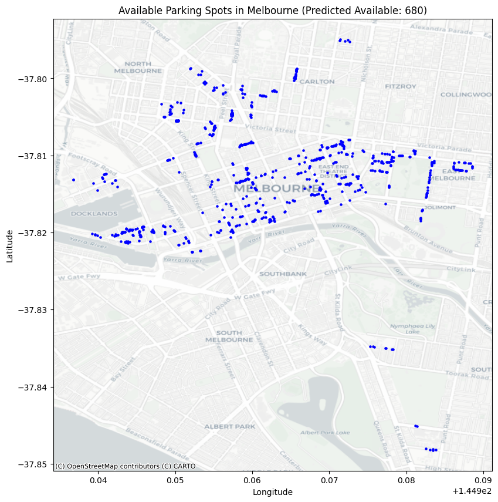

```python
import pandas as pd
import pytz
import numpy as np
import geopandas as gpd
import matplotlib.pyplot as plt
import contextily as ctx
from sklearn.preprocessing import MinMaxScaler
from sklearn.metrics import mean_squared_error
from tensorflow.keras.models import Sequential
from tensorflow.keras.layers import ConvLSTM2D, Dense, Flatten
from scipy.stats import ks_2samp, wasserstein_distance
from scipy.spatial.distance import jensenshannon
from datetime import timedelta

# Function to fetch and process the dataset for a specific time window
def fetch_and_process_data(hours_ago):
    base_url = 'https://data.melbourne.vic.gov.au/api/explore/v2.1/catalog/datasets/'
    dataset_id = 'on-street-parking-bay-sensors'
    url = f"{base_url}{dataset_id}/exports/csv"
    df = pd.read_csv(url, delimiter=';')

    def convert_utc_to_melbourne(utc_time_str):
        melbourne_zone = pytz.timezone('Australia/Melbourne')
        utc_time = pd.to_datetime(utc_time_str, utc=True)
        melbourne_time = utc_time.tz_convert(melbourne_zone)
        return melbourne_time

    columns_to_convert = ['lastupdated', 'status_timestamp']
    for column in columns_to_convert:
        if column in df.columns:
            df[column] = df[column].apply(lambda x: convert_utc_to_melbourne(x) if pd.notnull(x) else x)

    # Get data within the window of 2 hours ago and an additional 2 hours before that
    end_time = pd.Timestamp.now(pytz.timezone('Australia/Melbourne')) - timedelta(hours=hours_ago)
    start_time = end_time - timedelta(hours=2)
    df_filtered = df[(df['status_timestamp'] >= start_time) & (df['status_timestamp'] < end_time)]

    df_resampled = df_filtered.resample('3T', on='status_timestamp').agg({
        'kerbsideid': 'count'
    }).fillna(0)

    scaler = MinMaxScaler(feature_range=(0, 1))
    df_resampled_scaled = scaler.fit_transform(df_resampled)

    return df_filtered, df_resampled_scaled, scaler

# Split data into features (X) and targets (Y) with look-back window for spatio-temporal data
def split_spatio_temporal_data(df_resampled_scaled, time_steps=30, height=1, width=1):
    X, y = [], []
    for i in range(len(df_resampled_scaled) - time_steps - 1):
        X.append(df_resampled_scaled[i:(i + time_steps), 0].reshape(time_steps, height, width, 1))  # Spatio-temporal reshaping
        y.append(df_resampled_scaled[i + time_steps, 0])
    return np.array(X), np.array(y)

# ConvLSTM model creation for spatio-temporal data
def build_conv_lstm_model(time_steps=30, height=1, width=1):
    model = Sequential()
    model.add(ConvLSTM2D(filters=64, kernel_size=(1, 1), input_shape=(time_steps, height, width, 1), return_sequences=False))
    model.add(Flatten())
    model.add(Dense(1))  # Single output for regression
    model.compile(optimizer='adam', loss='mse')
    return model

# ConvLSTM Forecast function
def conv_lstm_forecast(df_resampled_scaled, scaler, time_steps=30, height=1, width=1):
    X, y = split_spatio_temporal_data(df_resampled_scaled, time_steps, height, width)

    # Check if we have enough data points
    if len(X) == 0:
        raise ValueError(f"Not enough data points for the given time_steps ({time_steps}). Try reducing the time_steps.")

    print(f"Number of available data points: {len(X)}")

    # Splitting the data into training and testing sets
    split_index = int(len(X) * 0.8)
    X_train, X_test = X[:split_index], X[split_index:]
    y_train, y_test = y[:split_index], y[split_index:]

    # Build and train ConvLSTM model
    conv_lstm_model = build_conv_lstm_model(time_steps, height, width)
    conv_lstm_model.fit(X_train, y_train, epochs=5, batch_size=32, verbose=2)

    # Generate predictions on the test data
    conv_lstm_predictions = conv_lstm_model.predict(X_test)

    # Inverse transform the predictions and actual values
    conv_lstm_predictions_inverse = scaler.inverse_transform(conv_lstm_predictions)
    y_test_inverse = scaler.inverse_transform(y_test.reshape(-1, 1))

    return conv_lstm_predictions_inverse, y_test_inverse

# Plot available spots on the map
def plot_available_spots(df, lstm_predictions):
    total_kerbside_ids = df['kerbsideid'].nunique()  # Total unique kerbside IDs
    forecast_occupied = lstm_predictions[-1][0]  # The forecasted occupied spots
    forecast_available = total_kerbside_ids - forecast_occupied  # Calculate available spots

    # Check if the location column has valid data
    if 'location' not in df.columns or df['location'].isnull().all():
        print("Error: No valid location data available for plotting.")
        return

    # Handle missing or malformed data in the location field
    df_available = df.dropna(subset=['location'])  # Drop rows where location is missing
    df_available['location'] = df_available['location'].astype(str)  # Ensure location is treated as a string

    # Directly split location into latitude and longitude without extra validation
    available_kerbside_ids = df_available[['kerbsideid', 'location']].drop_duplicates()
    location_split = available_kerbside_ids['location'].str.split(',', expand=True)

    if location_split.shape[1] != 2:
        print("Error: Location data is not split into two columns (latitude, longitude).")
        print(location_split.head())
        return

    available_kerbside_ids['Latitude'] = location_split[0].astype(float)
    available_kerbside_ids['Longitude'] = location_split[1].astype(float)

    # Plot available spots on a map
    gdf = gpd.GeoDataFrame(available_kerbside_ids, geometry=gpd.points_from_xy(available_kerbside_ids.Longitude, available_kerbside_ids.Latitude))
    gdf = gdf.set_crs(epsg=4326)

    ax = gdf.plot(figsize=(10, 10), color='blue', markersize=5)
    ctx.add_basemap(ax, crs=gdf.crs, source=ctx.providers.CartoDB.Positron)

    plt.title(f"Available Parking Spots in Melbourne (Predicted Available: {round(forecast_available)})")
    plt.xlabel("Longitude")
    plt.ylabel("Latitude")
    plt.show()

# Execute ConvLSTM model (spatio-temporal)
df, df_resampled_scaled, scaler = fetch_and_process_data(hours_ago=2)
conv_lstm_predictions, y_test_actual = conv_lstm_forecast(df_resampled_scaled, scaler, time_steps=30)

# Kolmogorov-Smirnov Test
ks_stat_conv_lstm, ks_p_value_conv_lstm = ks_2samp(conv_lstm_predictions.flatten(), y_test_actual.flatten())

# Earth Mover's Distance (EMD)
emd_conv_lstm = wasserstein_distance(conv_lstm_predictions.flatten(), y_test_actual.flatten())

# Jensen-Shannon Divergence (JSD)
jsd_conv_lstm = jensenshannon(conv_lstm_predictions.flatten(), y_test_actual.flatten())

# Print Results for ConvLSTM
print(f"ConvLSTM Model:")
print(f"Kolmogorov-Smirnov Statistic: {ks_stat_conv_lstm:.4f}, p-value: {ks_p_value_conv_lstm:.4f}")
print(f"Earth Mover's Distance (EMD): {emd_conv_lstm:.4f}")
print(f"Jensen-Shannon Divergence (JSD): {jsd_conv_lstm:.4f}")

# Plot the future available spots
plot_available_spots(df, conv_lstm_predictions)
```

## 9. Interpretation - Based on the results for Data Drift monitoring

Kolmogorov-Smirnov Statistic and p-value: Both models have a Kolmogorov-Smirnov Statistic of 1.0000 with a p-value of 0.3333.

Earth Mover's Distance (EMD)

The Earth Mover's Distance (EMD) measures the minimum "effort" required to transform one distribution into another. A smaller EMD value indicates that the predicted values are closer to the actual values.

Jensen-Shannon Divergence (JSD)